# Lesson 4 - Working With Matrices, Arrays and Lists

Stats 20 – Section 1 – Vivian Lew

Due July 7, 2020 by 11:59PM PDT

# 1. The Matrix (review and additional points)

Matrices (or more generally arrays) are multi-dimensional generalizations of vectors. Matrices are vectors that can be indexed by two indices (row, column) and Arrays can be indexed by more than two indices (e.g., row, column, page).

For example if the dimension vector for an array named ar, is c(3,4,2) then there are 3 * 4 * 2 = 24 entries in ar and the data vector keeps them in the order ar[1,1,1], ar[2,1,1], …, ar[2,4,2], ar[3,4,2].

```r
a <- c(seq(10, 120, 10), seq(100, 1200, 100))
a
```

```
##  [1]   10   20   30   40   50   60   70   80   90  100  110  120  100  200  300
## [16]  400  500  600  700  800  900 1000 1100 1200
```

We convert the vector a to an array, notice the build order, it’s by column then row.

```r
ar <- array(a, dim = c(3, 4, 2))
ar
```

```
## , , 1
##
##      [,1] [,2] [,3] [,4]
## [1,]   10   40   70  100
## [2,]   20   50   80  110
## [3,]   30   60   90  120
##
## , , 2
##
##      [,1] [,2] [,3] [,4]
## [1,]  100  400  700 1000
## [2,]  200  500  800 1100
## [3,]  300  600  900 1200
```

We can request specific values of ar using the extract operator. Individual elements of an array may be referenced by giving the name of the array followed by the subscripts in square brackets, separated by commas.

```r
ar[1,1,1]
```

```
## [1] 10
```

```r
ar[2,1,1]
```

```
## [1] 20
```

```r
ar[3,1,1]
```

```
## [1] 30
```

```r
ar[1,2,1]
```

```
## [1] 40
```

```r
ar[1,4,2]
```

```
## [1] 1000
```

```r
ar[2,4,2]
```

```
## [1] 1100
```

```r
ar[3,4,2]
```

```
## [1] 1200
```

Generally, subsections of an array may be specified by giving a sequence of index vectors in place of subscripts. However if any index position is given an empty (no) index vector, then the full range of that subscript is assumed.

In this example, HairEyeColor is a “built-in” dataset and it is also an array:

```r
HairEyeColor
```

```
## , , Sex = Male
##
##        Eye
## Hair    Brown Blue Hazel Green
##   Black    32   11    10     3
##   Brown    53   50    25    15
##   Red      10   10     7     7
##   Blond     3   30     5     8
##
## , , Sex = Female
##
##        Eye
## Hair    Brown Blue Hazel Green
##   Black    36    9     5     2
##   Brown    66   34    29    14
##   Red      16    7     7     7
##   Blond     4   64     5     8
```

```r
is.array(HairEyeColor)
```

```
## [1] TRUE
```

All of the Brown Hair/Brown Eye people, note the empty third index gives us both genders:

```r
HairEyeColor[2,1,]
```

```
##   Male Female
##     53     66
```

We could find a total

```r
sum(HairEyeColor[2,1,])
```

```
## [1] 119
```

Can you find blond Female with Blue eyes?

```r
HairEyeColor[4,2,2]
```

```
## [1] 64
```

Hair Color of Blue Eyed people (all hair colors and both genders in this dataset)

```r
HairEyeColor[ , 2, ]
```

```
##        Sex
## Hair    Male Female
##   Black   11      9
##   Brown   50     34
##   Red     10      7
##   Blond   30     64
```

Extra… some of you might say, well… how do I get the total?

Just use some math. We don’t see the apply function until about week 4, but it’s very useful. It’s syntax is basically apply(data, dimension, function) so the next line is interpreted as "compute the sum of every row for the data matrix (table) described by HairEyeColor[,2,]

```r
is.matrix(HairEyeColor[,2,])
```

```
## [1] TRUE
```

```r
apply(HairEyeColor[,2,], 1, sum)
```

```
## Black Brown   Red Blond
##    20    84    17    94
```

In this case, we’re summing the columns:

```r
apply(HairEyeColor[,2,], 2, sum)
```

```
##   Male Female
##    101    114
```

For the grand total of blue eyed people, it’s simpler because we just need to sum it all up, we aren’t interested in any of the dimensions:

```r
sum(HairEyeColor[,2,])
```

```
## [1] 215
```

# 2. Matrix Math

The matrix is an important special case of the array and R contains many operators and functions that are available only for matrices. For example t(X) is the matrix transpose function applied to a matrix named “X”. The functions nrow(A) and ncol(A) give the number of rows and columns in a matrix named “A” respectively.

## Matrix Multiplication (from CRAN)

There is a high variance in math training in Stat 20 (e.g., some students haven’t taken Math 33A and some have completed Math 115A with A+), so we won’t spend much time on Matrix Multiplication except to say that R has all the operations you need.

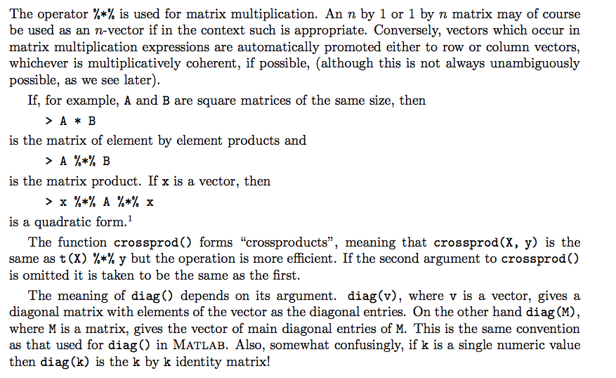

I can’t stress it enough, you should at minimum complete Math 33A if you’re planning to work with data in the future. And if you’re planning to be a data scientist and complete an MS or PhD in a Stat department, definitely complete Math 115A. The first line of the next screen capture from CRAN on Inverting matrices says it all. Solving linear equations is the inverse of matrix multiplication.

## Linear equations and inversion (from CRAN)

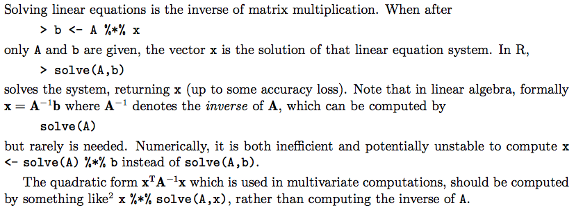

Here’s a nice readable discussion from the web and for me, it points us towards upper division statistics: https://datascienceplus.com/linear-regression-from-scratch-in-r/

We won’t be running linear regression from matrix operations in Stat 20 (that’s upper division work, like 101A) but we will run it from lm() and spend time on the output of that function (later…)

# 3. The List and List Extraction

The List and List Extraction is introduced in lecture so the discussion will be brief here. The list is a useful data structure. It may contain any combination of R structures and objects. You can even have a list as a component of another list.

You can use the list() function to create a list, but frequently lists are created by other functions as output or by importing data such as webpages or JSON (Javascript Object Notation) files.

List components are always numbered and can be referred to by number or by name (if the components have names).

Let’s create one that will serve as a bridge between Stat 20 and Stat 101A, start with the built-in data frame cars (let’s review it):

```r
str(cars)
```

```
## 'data.frame':    50 obs. of  2 variables:
##  $ speed: num  4 4 7 7 8 9 10 10 10 11 ...
##  $ dist : num  2 10 4 22 16 10 18 26 34 17 ...
```

It’s a data.frame (which is a special kind of list) comprised of two vectors: speed and dist. These represent two pieces of information collected on 50 cars from the 1920s. We will model distance as a function of speed:

```r
MyModel <- lm(dist ~ speed, data = cars)
```

lm( ) the function for linear models  
dist is one of the vectors in the data frame cars  
the tilde is read “as a function of” speed is the other vector

we can summarize MyModel, this is a more proper use of summary()

```r
summary(MyModel)
```

```
##
## Call:
## lm(formula = dist ~ speed, data = cars)
##
## Residuals:
##     Min      1Q  Median      3Q     Max
## -29.069  -9.525  -2.272   9.215  43.201
##
## Coefficients:
##             Estimate Std. Error t value Pr(>|t|)
## (Intercept) -17.5791     6.7584  -2.601   0.0123 *
## speed         3.9324     0.4155   9.464 1.49e-12 ***
## ---
## Signif. codes:  0 '***' 0.001 '**' 0.01 '*' 0.05 '.' 0.1 ' ' 1
##
## Residual standard error: 15.38 on 48 degrees of freedom
## Multiple R-squared:  0.6511, Adjusted R-squared:  0.6438
## F-statistic: 89.57 on 1 and 48 DF,  p-value: 1.49e-12
```

Examining MyModel with str( ) reveals a lot

```r
str(MyModel)
```

```
## List of 12
##  $ coefficients : Named num [1:2] -17.58 3.93
##   ..- attr(*, "names")= chr [1:2] "(Intercept)" "speed"
##  $ residuals    : Named num [1:50] 3.85 11.85 -5.95 12.05 2.12 ...
##   ..- attr(*, "names")= chr [1:50] "1" "2" "3" "4" ...
##  $ effects      : Named num [1:50] -303.914 145.552 -8.115 9.885 0.194 ...
##   ..- attr(*, "names")= chr [1:50] "(Intercept)" "speed" "" "" ...
##  $ rank         : int 2
##  $ fitted.values: Named num [1:50] -1.85 -1.85 9.95 9.95 13.88 ...
##   ..- attr(*, "names")= chr [1:50] "1" "2" "3" "4" ...
##  $ assign       : int [1:2] 0 1
##  $ qr           :List of 5
##   ..$ qr   : num [1:50, 1:2] -7.071 0.141 0.141 0.141 0.141 ...
##   .. ..- attr(*, "dimnames")=List of 2
##   .. .. ..$ : chr [1:50] "1" "2" "3" "4" ...
##   .. .. ..$ : chr [1:2] "(Intercept)" "speed"
##   .. ..- attr(*, "assign")= int [1:2] 0 1
##   ..$ qraux: num [1:2] 1.14 1.27
##   ..$ pivot: int [1:2] 1 2
##   ..$ tol  : num 1e-07
##   ..$ rank : int 2
##   ..- attr(*, "class")= chr "qr"
##  $ df.residual  : int 48
##  $ xlevels      : Named list()
##  $ call         : language lm(formula = dist ~ speed, data = cars)
##  $ terms        :Classes 'terms', 'formula'  language dist ~ speed
##   .. ..- attr(*, "variables")= language list(dist, speed)
##   .. ..- attr(*, "factors")= int [1:2, 1] 0 1
##   .. .. ..- attr(*, "dimnames")=List of 2
##   .. .. .. ..$ : chr [1:2] "dist" "speed"
##   .. .. .. ..$ : chr "speed"
##   .. ..- attr(*, "term.labels")= chr "speed"
##   .. ..- attr(*, "order")= int 1
##   .. ..- attr(*, "intercept")= int 1
##   .. ..- attr(*, "response")= int 1
##   .. ..- attr(*, ".Environment")=<environment: R_GlobalEnv>
##   .. ..- attr(*, "predvars")= language list(dist, speed)
##   .. ..- attr(*, "dataClasses")= Named chr [1:2] "numeric" "numeric"
##   .. .. ..- attr(*, "names")= chr [1:2] "dist" "speed"
##  $ model        :'data.frame':   50 obs. of  2 variables:
##   ..$ dist : num [1:50] 2 10 4 22 16 10 18 26 34 17 ...
##   ..$ speed: num [1:50] 4 4 7 7 8 9 10 10 10 11 ...
##   ..- attr(*, "terms")=Classes 'terms', 'formula'  language dist ~ speed
##   .. .. ..- attr(*, "variables")= language list(dist, speed)
##   .. .. ..- attr(*, "factors")= int [1:2, 1] 0 1
##   .. .. .. ..- attr(*, "dimnames")=List of 2
##   .. .. .. .. ..$ : chr [1:2] "dist" "speed"
##   .. .. .. .. ..$ : chr "speed"
##   .. .. ..- attr(*, "term.labels")= chr "speed"
##   .. .. ..- attr(*, "order")= int 1
##   .. .. ..- attr(*, "intercept")= int 1
##   .. .. ..- attr(*, "response")= int 1
##   .. .. ..- attr(*, ".Environment")=<environment: R_GlobalEnv>
##   .. .. ..- attr(*, "predvars")= language list(dist, speed)
##   .. .. ..- attr(*, "dataClasses")= Named chr [1:2] "numeric" "numeric"
##   .. .. .. ..- attr(*, "names")= chr [1:2] "dist" "speed"
##  - attr(*, "class")= chr "lm"
```

MyModel is a list, we can see its named components more clearly here:

```r
names(MyModel)
```

```
##  [1] "coefficients"  "residuals"     "effects"       "rank"
##  [5] "fitted.values" "assign"        "qr"            "df.residual"
##  [9] "xlevels"       "call"          "terms"         "model"
```

And as in previous places in Stat 20, there is great value placed on extracting values. We can work with a slightly simpler list derived from MyModel:

```r
MySummary <- summary(MyModel)
str(MySummary)
```

```
## List of 11
##  $ call         : language lm(formula = dist ~ speed, data = cars)
##  $ terms        :Classes 'terms', 'formula'  language dist ~ speed
##   .. ..- attr(*, "variables")= language list(dist, speed)
##   .. ..- attr(*, "factors")= int [1:2, 1] 0 1
##   .. .. ..- attr(*, "dimnames")=List of 2
##   .. .. .. ..$ : chr [1:2] "dist" "speed"
##   .. .. .. ..$ : chr "speed"
##   .. ..- attr(*, "term.labels")= chr "speed"
##   .. ..- attr(*, "order")= int 1
##   .. ..- attr(*, "intercept")= int 1
##   .. ..- attr(*, "response")= int 1
##   .. ..- attr(*, ".Environment")=<environment: R_GlobalEnv>
##   .. ..- attr(*, "predvars")= language list(dist, speed)
##   .. ..- attr(*, "dataClasses")= Named chr [1:2] "numeric" "numeric"
##   .. .. ..- attr(*, "names")= chr [1:2] "dist" "speed"
##  $ residuals    : Named num [1:50] 3.85 11.85 -5.95 12.05 2.12 ...
##   ..- attr(*, "names")= chr [1:50] "1" "2" "3" "4" ...
##  $ coefficients : num [1:2, 1:4] -17.579 3.932 6.758 0.416 -2.601 ...
##   ..- attr(*, "dimnames")=List of 2
##   .. ..$ : chr [1:2] "(Intercept)" "speed"
##   .. ..$ : chr [1:4] "Estimate" "Std. Error" "t value" "Pr(>|t|)"
##  $ aliased      : Named logi [1:2] FALSE FALSE
##   ..- attr(*, "names")= chr [1:2] "(Intercept)" "speed"
##  $ sigma        : num 15.4
##  $ df           : int [1:3] 2 48 2
##  $ r.squared    : num 0.651
##  $ adj.r.squared: num 0.644
##  $ fstatistic   : Named num [1:3] 89.6 1 48
##   ..- attr(*, "names")= chr [1:3] "value" "numdf" "dendf"
##  $ cov.unscaled : num [1:2, 1:2] 0.19311 -0.01124 -0.01124 0.00073
##   ..- attr(*, "dimnames")=List of 2
##   .. ..$ : chr [1:2] "(Intercept)" "speed"
##   .. ..$ : chr [1:2] "(Intercept)" "speed"
##  - attr(*, "class")= chr "summary.lm"
```

And practice extracting… recall the extract operators are [ , [[ , and $

Let’s extract “r.squared” and see all 3 extract operators in action:

```r
MySummary[8]
```

```
## $r.squared
## [1] 0.6510794
```

```r
class(MySummary[8])
```

```
## [1] "list"
```

```r
MySummary[[8]]
```

```
## [1] 0.6510794
```

```r
class(MySummary[[8]])
```

```
## [1] "numeric"
```

```r
MySummary$r.squared
```

```
## [1] 0.6510794
```

```r
class(MySummary$r.squared)
```

```
## [1] "numeric"
```

The last two do exactly the same thing, the difference is one uses the index value the other use the name. The first one (using the single square bracket) creates a list.

# 4. Questions

1. Please (a) Create a 2 by 4 matrix and please populate the matrix *by row* with the values 18.1, 15.5, 14.7, 17.4, 12.6, 15.5, 15.2, and 13.2, in that order and assign it to an object. (b) Overwrite the second column of the matrix from (a) with the square root of the values from the original second column. (c) Does R return a matrix or a vector when you remove both the first row and the fourth column from (b) and store it as a new object?
2. Using Lesson3SU.RData (you can find it under Lesson 3), please (a) create a single list object (name it what you want) using all (i.e., Q4B, Q4C, etc.) of the R objects that were stored in Lesson3SU.RData.

```
## Q4B :  Named num [1:3741] 0 31 14 22 0 19 0 4 144 0 ...
## Q4C :  chr [1:3741] "South Carolina" "Louisiana" "Virginia" "Idaho" "Iowa" ...
## Q4D331 :  num [1:2434] 0 1 0 3 0 0 0 2 0 0 ...
## Q4D430 :  num [1:3177] 0 10 4 16 0 10 0 3 63 0 ...
## Q4D531 :  num [1:3526] 0 23 12 22 0 19 0 3 120 0 ...
## Q4D614 :  num [1:3741] 0 31 14 22 0 19 0 4 144 0 ...
```

Then (b) run a str() on your list object so that we can see it was correctly done.

3. Please show us how to calculate the mean of the residuals using MySummary (created above, you’ll need to copy the code to re-create it)
4. Issue the following two functions separately (one will generate an error – don’t include the code in your submission, just write about the results)

```r
plot(MyModel)
```

```r
plot(MySummary)
```

What was the result and given what you have learned about R as of this, how would you explain the very different outcome (like why does the first plot generate plots but the second doesn’t even though they are both list objects?) to someone who hasn’t learned about R yet? Don’t worry about getting this exactly correct, I just want to see how you are thinking at this point.

# 5. What to Turn in For Credit

- Answers to the questions in 4.
- Name your file Lastname_Firstname_Lesson04.Rmd a model appears in the next link
- Submit a .Rmd file and the .html knitted/rendered result to the appropriate link in Week 2 no later than 7/7/2020 11:59PM PDT.